# TU OMICS: Genomic data

Practicals

Boris Hejblum

October 11<sup>th</sup>, 2019

**NB:** the 4<sup>th</sup> SubSeries of data is ommited because it features longitudinal data

## Necessary packages

Please install the following packages that will be useful during this practical:

- `dplyr`
- `flashClust`
- `edgeR`
- `limma`
- `UpSetR`

**WARNING**: some of those are from [`Bioconductor`](https://www.bioconductor.org)

```r
library(dplyr)
library(edgeR)
library(limma)
library(UpSetR)
library(flashClust)
```

# Context

This practicals will be based on the public data provided alongside the (Singhania et al. 2018) article on the Gene Expression Omnibus website data repository under the superserie accession number `GSE107995` and that studied the transcriptional signature of active human tuberculosis (TB) infection.

# Data Management

## Public data import

> 0.a) first download both the *raw* and *`edgeR`-normalized* `xlsx` files from [GEO](https://www.ncbi.nlm.nih.gov/geo/query/acc.cgi?acc=GSE107995) for all 3 subseries:
> - `GSE107991`
> - `GSE107992`
> - `GSE107993`

> 0.b) read through the code below and try to understand the operation performed. In particular, have a look at the `GSE107991_metadata` object (*tip*: it is a `S4 object`, so use the `@` operator)

```r
# DATA ----
rm(list = ls())

library(GEOquery)
library(readxl)

London_norm <- read_excel("GSE107991_edgeR_normalized_Berry_London.xlsx")  # edgeR preprocessed
SouthAfrica_norm <- read_excel("GSE107992_edgeR_normalized_Berry_SouthAfrica.xlsx")
Leicester_norm <- read_excel("GSE107993_edgeR_normalized_Leicester_non_progressor_longitudnal_only.xlsx")  # raw counts
London_raw <- read_excel("GSE107991_Raw_counts_Berry_London.xlsx")  # raw counts
SouthAfrica_raw <- read_excel("GSE107992_Raw_counts_Berry_SouthAfrica.xlsx")  # raw counts
Leicester_raw <- read_excel("GSE107993_Raw_counts_Leicester_non_progressor_longitudnal_only.xlsx")  # raw counts

# metadata
GSE107991_metadata <- GEOquery::getGEO("GSE107991", GSEMatrix = FALSE)  #London
GSE107992_metadata <- GEOquery::getGEO("GSE107992", GSEMatrix = FALSE)  # SouthAfrica
GSE107993_metadata <- GEOquery::getGEO("GSE107993", GSEMatrix = FALSE)  #Leicester

get_info <- function(i, meta) {
    name <- meta@gsms[[i]]@header$source_name_ch1
    name <- gsub("Active_TB", "ActiveTB", name)
    name <- gsub("Test_set", "TestSet", name)
    name <- gsub("Validation_set", "ValidationSet", name)
    name <- gsub("Non_progressor", "NonProgressor", name)
    res <- unlist(strsplit(name, split = "_"))
    res <- c(res, meta@gsms[[i]]@header$title)
    res
}
infos_london <- sapply(1:length(GSE107991_metadata@gsms), FUN = get_info, meta = GSE107991_metadata)
infos_df_london <- cbind.data.frame(GSMID = names(GSE107991_metadata@gsms),
    t(infos_london))
rownames(infos_df_london) <- names(GSE107991_metadata@gsms)
colnames(infos_df_london)[-1] <- c("Cohort", "Location", "Set", "Status", "SampleName")

infos_sf <- sapply(1:length(GSE107992_metadata@gsms), FUN = get_info, meta = GSE107992_metadata)
infos_df_sf <- cbind.data.frame(GSMID = names(GSE107992_metadata@gsms), t(infos_sf))
rownames(infos_df_sf) <- names(GSE107992_metadata@gsms)
colnames(infos_df_sf)[-1] <- c("Cohort", "Location", "Set", "Status", "SampleName")

infos_leicester <- sapply(1:length(GSE107993_metadata@gsms), FUN = get_info,
    meta = GSE107993_metadata)
infos_df_leicester <- cbind.data.frame(GSMID = names(GSE107993_metadata@gsms),
    t(infos_leicester))
rownames(infos_df_leicester) <- names(GSE107993_metadata@gsms)
colnames(infos_df_leicester)[-1] <- c("Cohort", "Location", "Status", "Set",
    "SampleName")
infos_df_leicester <- infos_df_leicester[, c(1, 2, 3, 5, 4, 6)]

infos_singhania <- rbind.data.frame(infos_df_london, infos_df_sf, infos_df_leicester)
expr_singhania_raw <- merge(x = merge(x = London_raw, y = SouthAfrica_raw, by = c(1:3)),
    y = Leicester_raw, by = c(1:3))
expr_singhania_norm <- merge(x = merge(x = London_norm, y = SouthAfrica_norm,
    by = c(1:3)), y = Leicester_norm, by = c(1:3))

save(infos_singhania, expr_singhania_raw, expr_singhania_norm, London_norm,
    SouthAfrica_norm, Leicester_norm, file = "SinghaniaTB_data.Rdata")
```

Now let’s start from the data set `expr_singhania_raw` and replicate the normalization steps that were performed in (Singhania et al. 2018).

## *Filtering*

The counts matrix outputted from the alignement usually contains many genes that are never observed.

> 1.a) remove the genes that are never observed, i.e. with 0 counts in every samples using the `dplyr::select()`, `rowSums()` and `dplyr::filter`() functions.

```r
dim(expr_singhania_raw)
```

```
## [1] 58051   242
```

```r
# removing genes never observed
gene_no0 <- rowSums(dplyr::select(expr_singhania_raw, -dplyr::starts_with("Gene"))) >
    0
table(gene_no0)
```

```
## gene_no0
## FALSE  TRUE
##  6443 51608
```

```r
expr_singhania_raw_no0 <- dplyr::filter(expr_singhania_raw, gene_no0)
dim(expr_singhania_raw_no0)
```

```
## [1] 51608   242
```

Low counts are still badly understood by the community and their measure is less reliable than higher counts, therefore it is common to remove genes with very low counts. In particular, Singhania *et al* considered only genes “expressed with counts per million (CPM) > 2 in at least five samples” (such filters can seem a bit *ad hoc*).

> 1.b) Compute the counts per million and keep only the genes that have a cpm>2 in at least 5 samples.

**NB:** $cpm(x_{ig}) = \dfrac{x_{ig} \times 1,000,000}{\sum_{g=1}^Gx_{ig}}$ with $x_g$ the observed raw count for the gene $g$ in sample $i$.

```r
mycpmfun <- function(x) {
    return((x/sum(x)) * 10^6)
}
cpm <- apply(dplyr::select(expr_singhania_raw_no0, -starts_with("Gene")), MARGIN = 2,
    FUN = mycpmfun)
expr_singhania_raw_no0_cpm2p <- dplyr::filter(expr_singhania_raw_no0, rowSums(cpm >
    2) > 5)
dim(expr_singhania_raw_no0_cpm2p)
```

```
## [1] 15190   242
```

> 1.c) Finally keep only the protein coding genes (i.e. for which `Gene_biotype` is `protein_coding`)

```r
gene_pc <- expr_singhania_raw_no0_cpm2p$Gene_biotype == "protein_coding"
table(gene_pc)
```

```
## gene_pc
## FALSE  TRUE
##  2763 12427
```

```r
expr_singhania_raw_no0_cpm2p_prot <- filter(expr_singhania_raw_no0_cpm2p, gene_pc)
dim(expr_singhania_raw_no0_cpm2p_prot)
```

```
## [1] 12427   242
```

## Normalization

> 2.a) Display the boxplots of each samples $log2$ raw counts (with the `log2()` function) alongside each other, as well as a barpot of the library sizes for each sample, colored by cohort location (tip: use “base `R`” graphics). Comment the need for normalization.

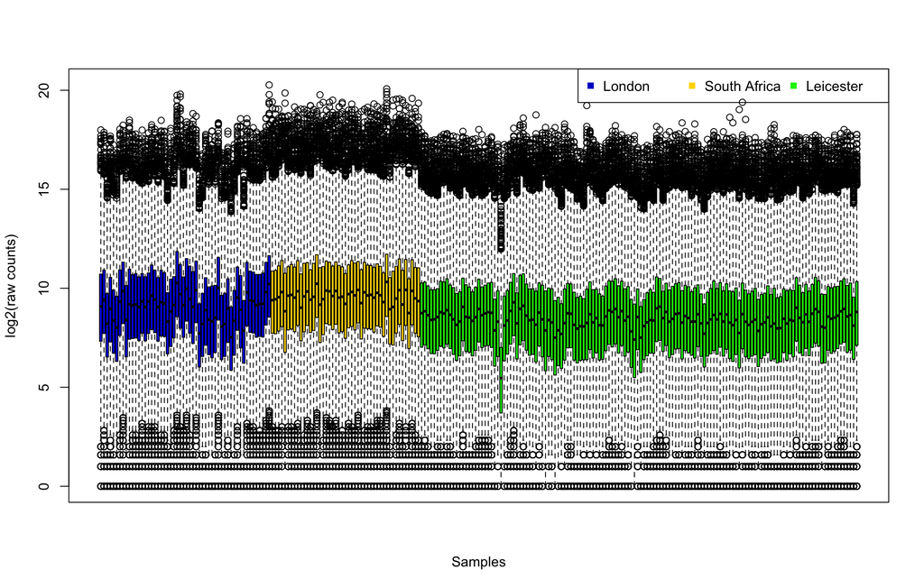

```r
bp_col <- infos_singhania$Location
levels(bp_col) <- c("blue2", "gold", "green2")
boxplot(log2(select(expr_singhania_raw_no0_cpm2p_prot, -starts_with("Gene"))),
    col = as.character(bp_col), xlab = "Samples", ylab = "log2(raw counts)",
    axes = FALSE)
axis(2)
box()
legend("topright", c("London", "South Africa", "Leicester"), col = c("blue3",
    "gold", "green2"), pch = 15, horiz = TRUE, bg = NA)
```

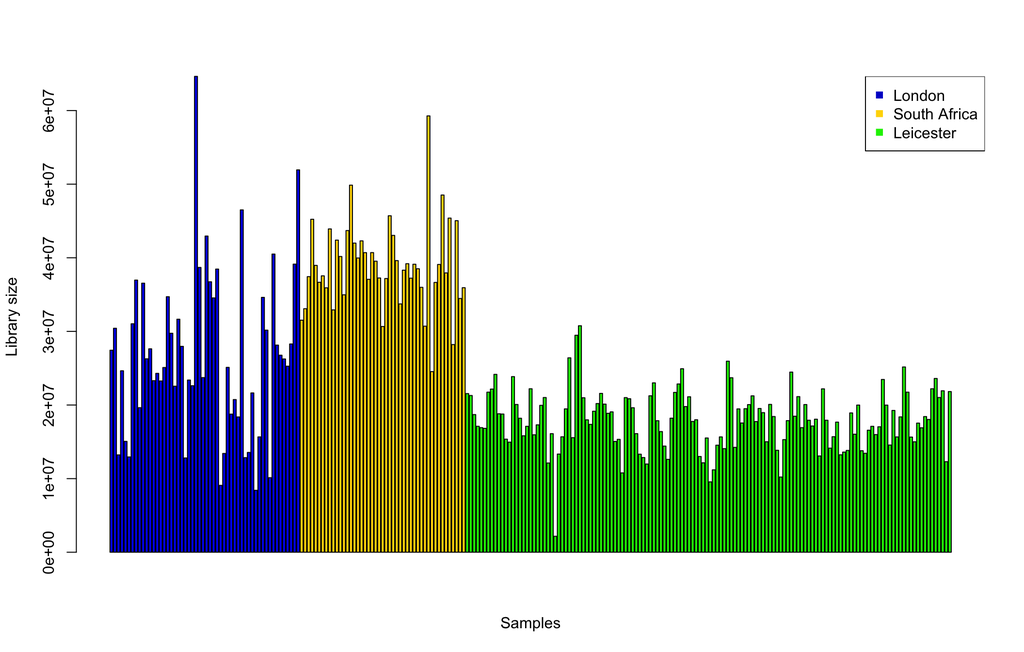

```r
barplot(colSums(select(expr_singhania_raw_no0_cpm2p_prot, -starts_with("Gene"))),
    col = as.character(bp_col), xlab = "Samples", ylab = "Library size", names.arg = "")
legend("topright", c("London", "South Africa", "Leicester"), col = c("blue3",
    "gold", "green2"), pch = 15, horiz = FALSE, bg = NA)
```

The sequencing depth problem is commonly treated with the *TMM normalization.* This normalization divides the raw count by the library size.

> 2.b) use the `edgeR::calcNormFactors()` function to compute the TMM normalization after converting the filtered count matrix to a `DGEList` object

```r
singhaniaDGE <- DGEList(counts = select(expr_singhania_raw_no0_cpm2p_prot, -starts_with("Gene")),
    samples = infos_singhania, genes = select(expr_singhania_raw_no0_cpm2p_prot,
        starts_with("Gene")))
singhaniaDGE_normfact <- edgeR::calcNormFactors(singhaniaDGE, method = "TMM")
```

> 2.c) use the `edgeR::cpm()` function to return the filtered, TMM normalized, log2-Counts per million.

```r
expr_singhania_no0_cpm2p_prot_TMMlog2cpm <- edgeR::cpm(singhaniaDGE_normfact,
    log = TRUE)
```

> 2.d) Compare the obtained values to the one shared publicly.

```r
dim(expr_singhania_no0_cpm2p_prot_TMMlog2cpm)
```

```
## [1] 12427   239
```

```r
dim(expr_singhania_norm)
```

```
## [1] 13441   242
```

```r
expr_singhania_no0_cpm2p_prot_TMMlog2cpm[1:5, 1:4]
```

| Berry_London_Sample1 | Berry_London_Sample2 | Berry_London_Sample3 | Berry_London_Sample4 |
| --- | --- | --- | --- |
| 4.650241 | 4.164666 | 3.882906 | 4.606822 |
| 4.687757 | 4.603745 | 4.352406 | 4.709899 |
| 2.396327 | 2.096244 | 2.238437 | 1.914652 |
| 10.272096 | 9.998178 | 10.107998 | 9.845746 |
| 1.951596 | 1.866684 | 2.173530 | 1.558944 |

```r
expr_singhania_norm[1:5, 4:7]
```

| Berry_London_Sample1 | Berry_London_Sample2 | Berry_London_Sample3 | Berry_London_Sample4 |
| --- | --- | --- | --- |
| 4.647009 | 4.193344 | 3.887871 | 4.603721 |
| 4.684619 | 4.633853 | 4.358676 | 4.707055 |
| 2.379097 | 2.107392 | 2.233367 | 1.891003 |
| 10.272479 | 10.032204 | 10.117594 | 9.846276 |
| 1.927926 | 1.873832 | 2.167779 | 1.528433 |

> 2.e) Display the boxplots of each samples $log2$-cpm normalized expressions alongside each other and comment.

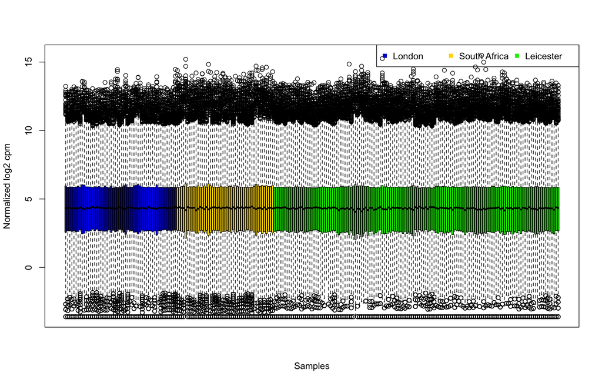

```r
bp_col <- infos_singhania$Location
levels(bp_col) <- c("blue2", "gold", "green2")
boxplot(expr_singhania_no0_cpm2p_prot_TMMlog2cpm, col = as.character(bp_col),
    xlab = "Samples", ylab = "Normalized log2 cpm", axes = FALSE)
axis(2)
box()
legend("topright", c("London", "South Africa", "Leicester"), col = c("blue3",
    "gold", "green2"), pch = 15, horiz = TRUE, bg = NA)
```

> 2.f) Display the dendrogram of the hierarchical clusterings using Wards method and the Euclidean distance comparing the raw counts and the normalized $log2$-cpm.

```r
deucl_raw <- dist(t(select(expr_singhania_raw_no0_cpm2p_prot, -starts_with("Gene"))))
deucl_norm <- dist(t(expr_singhania_no0_cpm2p_prot_TMMlog2cpm))
```

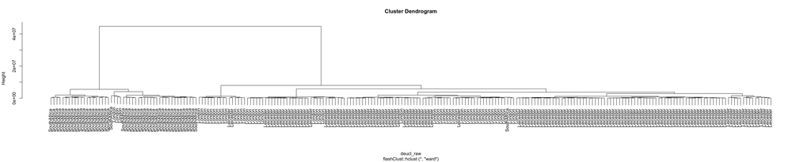

```r
plot(flashClust::hclust(deucl_raw, method = "ward"), labels = infos_singhania$Location)
```

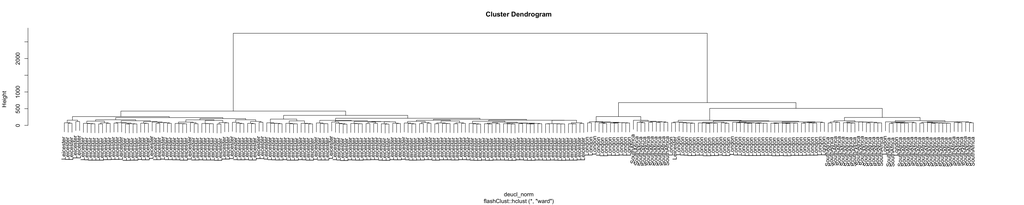

```r
plot(flashClust::hclust(deucl_norm, method = "ward"), labels = infos_singhania$Location)
```

# Differential expression

Let’s now focus on the first analysis performed by Singhania *et al.*, i.e. the analysis of the London Berry cohort alone, pooling together `Latent TB` and `Controls` to be compared to the `Active TB` individuals.

## Research question & design matrix

> 3.a) Formulate the research question of interest here.

Which genes are significantly differnetially expressed bewteen the Active TB patients on the one hand, and the other patients (*LTBI* and *Controls* pooled together) in the London test dataset ?

> 3.b) With the function `model.matrix()` generate a model matrix for the (generalized) linear model that you will use to answer that question.

```r
singhaniaLondonDGE_normfact <- singhaniaDGE_normfact[, singhaniaDGE_normfact$samples$Location ==
    "London"]
design <- as.data.frame(model.matrix(~Status, data = infos_singhania[infos_singhania$Location ==
    "London", ]))
design <- mutate(design, ActiveTB = 1 - (StatusLTBI + StatusControl))
design <- select(design, -starts_with("Status"))
```

## `edgeR` pipeline

(Robinson, McCarthy, and Smyth 2010)

> 4.a) Using `edgeR::estimateCommonDisp()` add a (common) dispertion estimate to the DGE object

```r
singhaniaLondonDGE_normfact_commondisp <- edgeR::estimateCommonDisp(singhaniaLondonDGE_normfact)
```

> 4.b) Using `edgeR::glmFit()` and `edgeR::glmLRT()` functions, identify the differentially expressed genes (adjusted p-value < 5% and | log-FoldChange | > 1 )

```r
fit <- glmFit(singhaniaLondonDGE_normfact_commondisp, design)
lrt <- glmLRT(fit, coef = 2)
signif_edgeR <- decideTestsDGE(lrt, adjust.method = "BH", p.value = 0.05, lfc = 1)
summary(signif_edgeR)
```

```
##        ActiveTB
## Down         49
## NotSig    12168
## Up          210
```

```r
genelist_edgeR <- singhaniaLondonDGE_normfact_commondisp$genes$Gene_name[as.logical(signif_edgeR)]
```

## `voom`-`limma` pipeline

(Smyth et al. 2002)

> 5.a) compute the precision weights with the `limma::voom()` function.

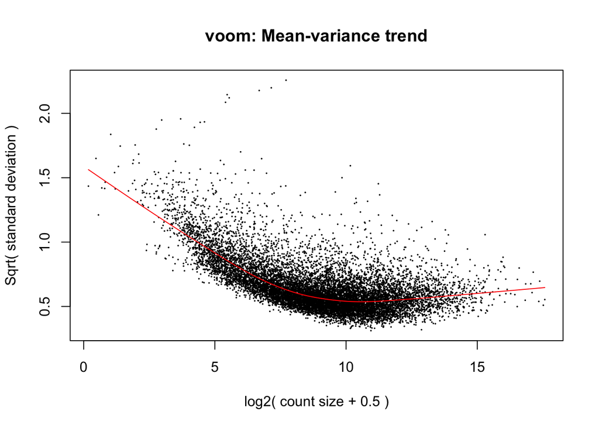

```r
# estimate the heteroscedasticity weights
v <- voom(singhaniaLondonDGE_normfact, design, plot = TRUE)
```

> 5.b) now apply the `limma` pipeline with the functions `limma::lmFit()`, `limma::eBayes()` and `limma::decideTests()`.

```r
# fit the gaussian linear model with precision weights v
fit <- lmFit(v, design)
# Empirical Bayes test
fit <- eBayes(fit, robust = TRUE)
voomlimma_signif <- decideTests(fit, adjust.method = "BH", p.value = 0.05, lfc = 1)
summary(voomlimma_signif)
```

```
##        (Intercept) ActiveTB
## Down           182       72
## NotSig        1124    12176
## Up           11121      179
```

```r
genelist_voomlimma <- singhaniaLondonDGE_normfact_commondisp$genes$Gene_name[as.logical(voomlimma_signif)]
```

## Discussion

> 6.a) Using an Up-Set diagramm (Conway, Lex, and Gehlenborg 2017) with the `UpSetR` package, compare the results between `edgeR` and `voom`-`limma`

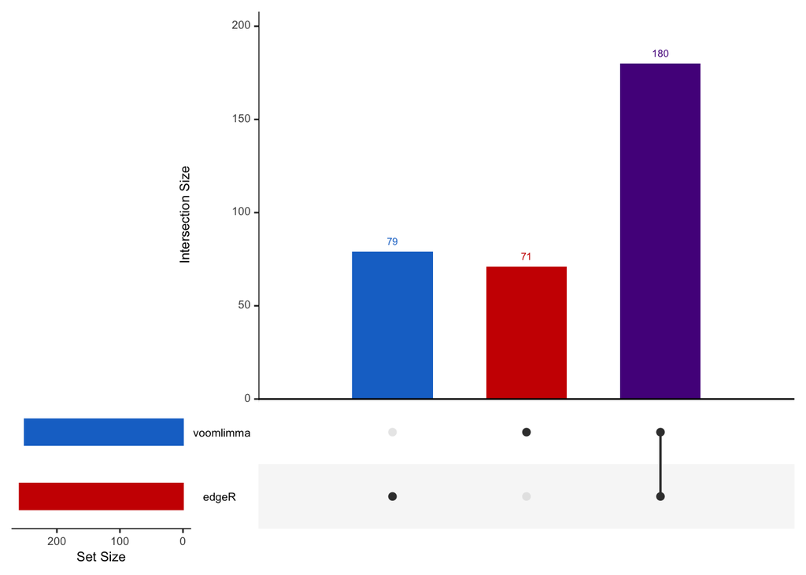

```r
upset_data <- cbind.data.frame(voomlimma = abs(voomlimma_signif[, 2]), edgeR = abs(signif_edgeR[,
    1]))
upset(data = upset_data, main.bar.color = c("dodgerblue3", "red3", "purple4"),
    sets.bar.color = c("red3", "dodgerblue3"))
```

> 6.b) Compare to the results from the Singhania *et al.* original article (in particular to the 373 gene signature). Can you list the elements that differed in their analysis compared to what you just did here ?

# Bibliography

Conway, Jake R, Alexander Lex, and Nils Gehlenborg. 2017. “UpSetR: An R Package for the Visualization of Intersecting Sets and Their Properties.” *Bioinformatics* 33 (18): 2938–40.

Robinson, Mark D, Davis J McCarthy, and Gordon K Smyth. 2010. “EdgeR: A Bioconductor Package for Differential Expression Analysis of Digital Gene Expression Data.” *Bioinformatics* 26 (1): 139–40.

Singhania, Akul, Raman Verma, Christine M Graham, Jo Lee, Trang Tran, Matthew Richardson, Patrick Lecine, et al. 2018. “A Modular Transcriptional Signature Identifies Phenotypic Heterogeneity of Human Tuberculosis Infection.” *Nature Communications* 9 (1): 2308.

Smyth, Gordon K, Matthew Ritchie, Natalie Thorne, James Wettenhall, Wei Shi, and Yifang Hu. 2002. “Limma: Linear Models for Microarray and Rna-Seq Data User’s Guide.”